# R Shiny Power To Choose Explorer

## [Interactive Project Link](https://ahmedtadde.shinyapps.io/electricityviz/)

This is a data analysis writeup (as of 10/09/15) for the R [Shiny](http://shiny.rstudio.com/) application - **Power to Choose (PTC)**, built to visualize *up-to-date* electricity plans and prices in the [ERCOT](http://www.ercot.com/) utility market.

The project is hosted on an [Shinyapps](https://www.shinyapps.io/) and all code and implementation are available on [Github](https://github.com/ahmedtadde/elctricityViz).

## Contents

- Summary
  - What is PTC
  - How to use PTC
  - What is lacking on PTC
  - Personal thoughts
- PTC Rankings
  - Cheap providers
  - Conclusion about REPs
  - Cheap is subjective
- PTC Market
  - Aggregating the data
  - Adjusting Binwidths
- Data
  - Data Source
  - Data Scraping
  - Data Munging
- Resources

## Summary

### What is PTC

[Power to Choose](http://www.powertochoose.org/) (PTC) is a consumer choice website set up by the [PUC](https://www.puc.texas.gov/) to provide customers a competitive platform to compare electricity plans and offers in Texas.

The native presentation of the data is in the form of an interactive table with search/filter widgets.

[figure not shown]

image-native

### How to use PTC

The general use of PTC is to quickly compare estimated prices at monthly usage thresholds (`500kWh`, `1000kWh`, `2000kWh`). The various Electricity Facts Label (EFL) price values corresponds to these usage thresholds.

From the main interface shown above, a user can gather information about companies, plans and pricing details. They can use the filter widgets on the left to filter data they want to see (e.g. specifying a price range or contract length range).

### What is lacking on PTC

The native PTC app is great for consumers to compare prices, but it is unable to display the information completely in one visualization i.e. the data is paginated and makes it difficult to ask questions on specific ranges and subsets.

The design of this application is to help empower *both consumers and analysts* with complete visualization of the data/market, through the use of histograms and scatterplots that are interactively updated based on user inputs.

For instance, all the data on PTC can be visualized concisely as a scatterplot sorted by price and REP rank.

And with the help on the filters widgets on the left,

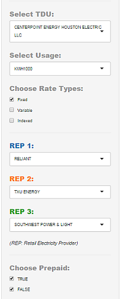

image-widgets

We can get real-time updates and full control of the dataset we wish to study. These widgets provide useful customization of the visualizations, some of which are listed below:

- **Changing the dataset** e.g. changing TDU company or usage values
- **Subsetting the data** e.g. selecting checkboxes
- **Highlighting data records** e.g. highlighting REPs

The writeup will go into detailed analysis on some of the more interesting findings in the visualization sections. An in-depth overview on data gathering, cleaning, and transformation of the original datasets will be outlined in the Data section.

At any time, feel free to experiment and draw your own conclusions with the interactive web application and refer to the `.R` files found on the [Github](https://github.com/ahmedtadde/elctricityViz) project site if you need details on code implementation.

## Personal thoughts

> With great marketing power and choices, comes great responsibility. Unfortunately, “cheap” prices may not always be the best deals on PTC.

Note that the existence of 3 usage-level pricing (`500kWh`, `1000kWh`, `2000kWh`) is one of the main drivers for the diversity of products that can be designed and created in the Texas electricity market.

For instance, a retail electric provider (REP) can offer a product which incurs additional charges if usage is below 800kWh. This causes the `500kWh` price to look unfavorable but the `1000kWh` and `2000kWh` prices to look much more favorable, which would help cater to customers who are shopping at higher usage price points.

However, this is also misinformation to an average customer who does not spend time using the filter/sorting widgets on the site (since the default sorting on PTC is at `1000kWh`). Many companies have, and are still abusing this fact to create attractive but misleading prices.

> My hope is that this walkthrough and application will help the general user be more informed about the choices they make.

<sub>(back to contents)</sub>

## PTC Rankings

### Cheap providers

In the `Rankings` tab of the application, there is a scatterplot that effectively displays the price spread by REP. The scatterplot is sorted by REP in descending price, so the cheapest provider will always be displayed on the *top-left* section of the map.

By selecting a specified usage value, and highlighting a few retail electric providers (REP) of interest, we can get a quick view on the prices in the selected market.

### Conclusion about REPs

This plot gives a quick indication on the price spread in the market and a sense on the “potential roles” of various REP in the market. We identify some interesting clusters:

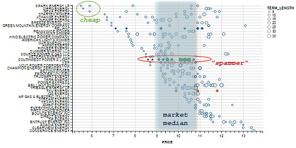

image-scatterplot-comments

- **Cheap**: Only a few REPs are low-price providers.
- **Market median**: Most REPS are clustered around the market-consolidated median price.
- **Spammer**: REPs that offer many plans are what I call *“PTC-spammers”*. This could be a viable technique to overpopulate their plans more frequently across the site for a chance of customers enrolling by accident.

In addition to deriving information from the scatterplot, I have created a short `Summary` section that provides useful statistics on the selected dataset/market (e.g. `Best`, `Top 10`, `Top 30`, `Mean`, `Top 10 REPS`).

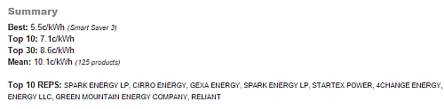

image-summary

### Cheap is subjective

Just as we mentioned earlier that REPs are able to create products that look seemingly cheap at a specified EFL usage (usually at `1000kWh` which is the default price sorting at PTC), we need to be careful on the price ranks of these companies, and make sure that the market that we carved out using the widget selections and filtering is indeed the subset of electricity plans we are interested in looking at.

For example, with a **default** PTC selection viewing all plans at **`1000kWh`**, the cheapest providers are `SPARK`, `CIRRO`, `GEXA`, `STARTEX` (see below).

However, selecting criteria for **100% renewable energy** and a **usage level of `2000kWh`** leads to a different ranking of cheapest providers, which are now listed as `BREEZE`, `GREEN MOUNTAIN`, `4CHANGE` (see below)

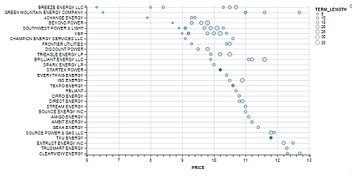

image-scatterplot-renewable

> Author’s note: Make sure that price is not the only criteria you are shopping with!

<sub>(back to contents)</sub>

## PTC Market

### Aggregating the data

Our previous scatterplot information can be aggregated into price buckets to get a more natural feel for the market (if we are not concerned with details of individual companies). Here’s the same results, as displayed in the `Market` tab of the application, when we choose to use a histogram instead of a scatterplot.

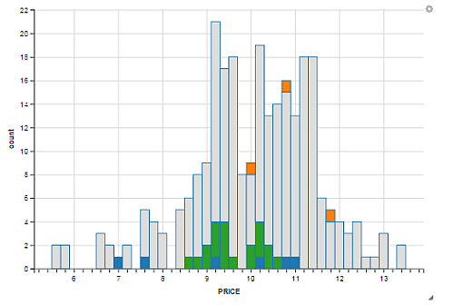

image-histogram

### Adjusting Binwidths

By simply adjusting the binwidth with the widget, we can reallocate the data in the histogram to a wider binwidth. The following histogram shows the same data plotted with a price binwidth of 1.0c/kWh as opposed to 0.2c/kWh used in the previous histogram.

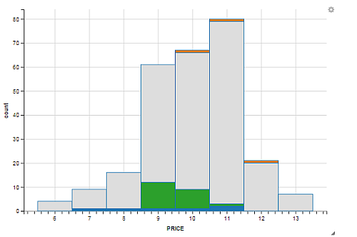

image-histogram-large-bin

This wraps up the data visualization sections of the web application. These interactive and dynamic visualizations are made possible by `ggvis`, which is a new library being developed by Hadley Wickham. `ggvis` is a relatively new library, so a lot of the methods and visualizations are limited in use, and are somewhat difficult to generate at a higher customized level. At this point, I would recommend using `ggplot2` over `ggvis`, but this application was an experiment in trying out the new visualization library that Hadley is working on :)

<sub>(back to contents)</sub>

## Data

> This section provides details on the data source and processes that go towards scraping and munging the initial unorganized data into a consolidated R dataframe that is used in the Shiny app. We will make references to the files on the [Github](https://github.com/ahmedtadde/elctricityViz) project.

All data is owned by the [Power to Choose](http://www.powertochoose.org/) made available by the [PUC](https://www.puc.texas.gov/). I am not affiliated with the PUC, and this writeup and application is purely for practicing and sharing thoughts behind data management and visualization.

If you are not interested in the data background and processes, feel free to jump back to the visualization sections!

### Data Source

The PTC data is conveniently provided as a organized csv download file accessed from http://www.powertochoose.org/en-us/Plan/ExportToCsv

For the remainder of the data walkthrough, we will work with files in the [Github](https://github.com/ahmedtadde/elctricityViz) repository.

But first, let’s scrape the data!

### Data Scraping

Open the `/data/functions.R` file and let’s build a function for pulling the data from the URL:

```r
# =========================================================================
# function get.data
#
# @description: get data from url or csv file saved in repository (for faster data loading)
# @return: cleaned data ready for use by objects in server.R file.
# =========================================================================
get.data <- function(update = NULL) {

  if(is.null(update)){

    return(setkey(fread("./data/data.csv")[, c("PREPAID","TOU","PROMOTION"):=
                                             list(toupper(as.character(PREPAID)),
                                                  toupper(as.character(TOU)),
                                                  toupper(as.character(PROMOTION))
                                                  )
                                          ], ID
                  )
           )

  }else{

    if(update %in% c("update", "Update","yes","Yes","new","New"))

      "http://www.powertochoose.org/en-us/Plan/ExportToCsv" %>%

        fread(
          header=TRUE,
          stringsAsFactors=FALSE
        ) %>%

        clean.data() %>%

        fwrite(file="./data/data.csv")

    return(setkey(fread("./data/data.csv")[, c("PREPAID","TOU","PROMOTION"):=
                                             list(toupper(as.character(PREPAID)),
                                                  toupper(as.character(TOU)),
                                                  toupper(as.character(PROMOTION))
                                                  )
                                          ], ID
                  )
           )
  }
}
```

```r
# As defined above, a value of NULL for update means that
# we want the APP to use the data version available as a
# csv File in the data repository. Any other string passed
# to update will instead download the data straight
# from the site.

df = get_df(update = NULL )
```

At this point, the data that we read in has native column headers and wrong data types (most of them are converted to `string` when we used the `stringsAsFactors=FALSE` to avoid conversions to the “difficult-to-deal-with” `factors` object type in R).

We now tidy the data `df` the data.table way. While the syntax of [datatable](https://github.com/Rdatatable/data.table/wiki) isn’t as readable as [dplyr](http://cran.rstudio.com/web/packages/dplyr/vignettes/introduction.html), it’s speed and simplicity of data manipulations is a great asset for any data wrangling task.

> The rest of the data section assumes some knowledge of data.table and pipeline processing using the `%>%` operator. Please check out this `data.table` [cheatsheet](https://s3.amazonaws.com/assets.datacamp.com/img/blog/data+table+cheat+sheet.pdf) to assist in following the code.

### Data Munging

We will abstract most of the cleaning logic in the function `clean`

The implementation for `clean` is provided below and we’ll expalin the major workflow below:

```r
# =========================================================================
# function:  clean.data
# @description: Renaming data.table columns, subset and define the types of columns
#               of interest
# @return: cleaned data.table
# =========================================================================
clean.data <- function(df){
  columns <- c("ID", "TDU", "REP", "PRODUCT",
               "KWH500", "KWH1000", "KWH2000",
               "FEES", "PREPAID", "TOU",
               "FIXED", "RATE_TYPE", "RENEWABLE",
               "TERM_LENGTH", "CANCEL_FEE", "WEdBSITE",
               "TERMS", "TERMS_URL", "PROMOTION", "PROMOTION_DESCRIPTION",
               "EFL_URL", "ENROLL_URL", "PREPAID_URL", "ENROLL_PHONE"
              )

  setnames(df, names(df)[1:24],  columns)  # rename columns
  rm(columns)

  return(

    df[, .(ID, TDU, REP, PRODUCT,
           KWH500, KWH1000, KWH2000,
           RATE_TYPE, TERM_LENGTH, RENEWABLE,
           PREPAID, TOU, PROMOTION, EFL_URL
           )

      ][,
        # convert units from $/kWh to c/kWh
        c("KWH500","KWH1000","KWH2000") := list(
            as.numeric(KWH500) * 100,
            as.numeric(KWH1000) * 100,
            as.numeric(KWH2000) * 100
          )
      ]
  )
}
```

Our data `df` is now nicely organized with well-named headers, and we can now load this into our `shiny` application through `global.R` (calling it once). In `server.R`, there are a lot more data manipulations used to generate unique visualizations, but the basis for these manipulations depend on the data that we have organized cleanly in this step.

For a sneak peek, our cleaned `df` now looks like this:

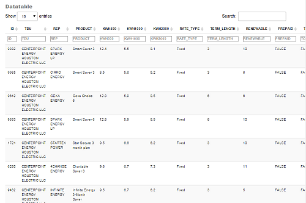

image-datatable

And that’s all to the data lifecycle section of the guide!

<sub>(back to contents)</sub>

## Resources

- [Power to Choose](http://www.powertochoose.org/)
- [PUC](https://www.puc.texas.gov/)
- [ERCOT](http://www.ercot.com/)
- [Shiny](http://shiny.rstudio.com/)
- [datatable](https://github.com/Rdatatable/data.table/wiki)
- [dplyr](http://cran.rstudio.com/web/packages/dplyr/vignettes/introduction.html)
- [Shinyapps](https://www.shinyapps.io/)
- [cheatsheet](https://s3.amazonaws.com/assets.datacamp.com/img/blog/data+table+cheat+sheet.pdf)

<sub>(back to contents)</sub>